# Toronto AirBNB Analysis

```r
# Load packages
library(here)
library(tidyverse)
library(gt)
library(e1071)
library(scales)
library(corrplot)
library(caret)
library(randomForest)
library(glmnet)
library(gbm)
```

```r
# Read in data
data  <- read_csv(here("inputs//data_prep.csv"))
data <- data %>%
  mutate(room_type = as.factor(room_type), license = as.factor(license))
```

# Introduction

For this analysis we’re explore the listings data of Airbnb rentals in Toronto. The data can be found at [link](http://insideairbnb.com/get-the-data/)

We’re primarily interested in the rental price however we’ll explore the entire dataset for anything interesting and visualize the results. The analysis will conclude with a model for predicting rental prices.

We’ve previously removed all listings with no reviews, we also remove all listings with no availability within the next year as these are likely no longer actively being rented and removed NA columns from the data.

# Data Exploration

We’ll generate some initial summary statistics of the various predictors to get started:

```r
# Check Summary Statistics
summary(data)
```

```
##        id            listing_url          scrape_id
##  Min.   :8.077e+03   Length:9358        Min.   :2.023e+13
##  1st Qu.:2.568e+07   Class :character   1st Qu.:2.023e+13
##  Median :4.633e+07   Mode  :character   Median :2.023e+13
##  Mean   :2.448e+17                      Mean   :2.023e+13
##  3rd Qu.:6.565e+17                      3rd Qu.:2.023e+13
##  Max.   :8.411e+17                      Max.   :2.023e+13
##
##   last_scraped           source              name           description
##  Min.   :2023-03-09   Length:9358        Length:9358        Length:9358
##  1st Qu.:2023-03-10   Class :character   Class :character   Class :character
##  Median :2023-03-10   Mode  :character   Mode  :character   Mode  :character
##  Mean   :2023-03-09
##  3rd Qu.:2023-03-10
##  Max.   :2023-03-26
##
##  neighborhood_overview picture_url           host_id
##  Length:9358           Length:9358        Min.   :    22795
##  Class :character      Class :character   1st Qu.: 28909542
##  Mode  :character      Mode  :character   Median :113615879
##                                           Mean   :169614255
##                                           3rd Qu.:283517431
##                                           Max.   :506119636
##
##    host_url          host_name           host_since         host_location
##  Length:9358        Length:9358        Min.   :2009-06-22   Length:9358
##  Class :character   Class :character   1st Qu.:2015-03-16   Class :character
##  Mode  :character   Mode  :character   Median :2017-01-28   Mode  :character
##                                        Mean   :2017-05-09
##                                        3rd Qu.:2019-08-06
##                                        Max.   :2023-03-19
##
##   host_about        host_response_time host_response_rate host_acceptance_rate
##  Length:9358        Length:9358        Length:9358        Length:9358
##  Class :character   Class :character   Class :character   Class :character
##  Mode  :character   Mode  :character   Mode  :character   Mode  :character
##
##
##
##
```

[output cut: 137 more lines]

```
##  Min.   : 0.000
##  1st Qu.: 0.000
##  Median : 0.000
##  Mean   : 1.634
##  3rd Qu.: 2.000
##  Max.   :29.000
##
##  calculated_host_listings_count_shared_rooms reviews_per_month
##  Min.   : 0.00000                            Min.   : 0.010
##  1st Qu.: 0.00000                            1st Qu.: 0.300
##  Median : 0.00000                            Median : 0.770
##  Mean   : 0.05076                            Mean   : 1.412
##  3rd Qu.: 0.00000                            3rd Qu.: 2.000
##  Max.   :14.00000                            Max.   :13.200
##
```

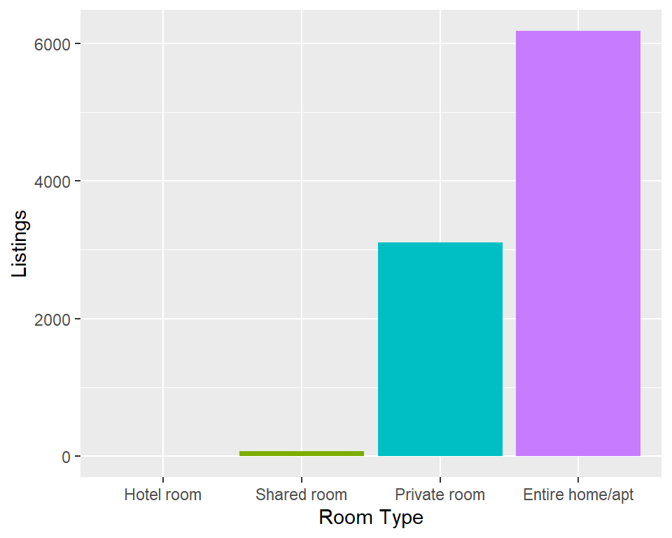

```r
data %>%
  select(room_type) %>%
  group_by(room_type) %>%
  summarize(listings = n()) %>%
  ungroup() %>%
  mutate(room_type = fct_reorder(room_type, listings)) %>%
  ggplot(aes(x = room_type, y = listings, fill = room_type)) +
  geom_bar(stat = "identity") +
  theme(legend.position = "none") +
  xlab("Room Type") +
  ylab("Listings")
```

Lets now look at the distribution of rental prices:

[figure not shown]

```r
ggplot(data, aes(x = price)) +
  geom_histogram(binwidth = 10, fill = "blue", color = "black") +
  labs(title = "Distribution of Airbnb Rental Prices",
       x = "Price",
       y = "Count")
```

```r
dim(data %>%
  filter(price > 5000))[1]
```

```
## [1] 3
```

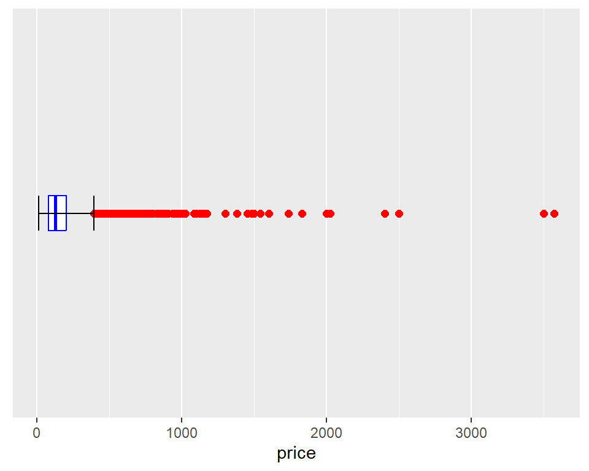

```r
data %>%
  filter(price < 5000) %>%
  ggplot(aes(x = price)) +
  geom_boxplot(color = "blue", outlier.color = "red", outlier.size = 2) +
  scale_x_continuous(breaks = c(0,1000,2000, 3000, 4000, 5000)) +
  ylim(-4,4) +
  stat_boxplot(geom ='errorbar') +
  theme(axis.title.y = element_blank(),
              axis.text.y = element_blank(),
              axis.ticks.y = element_blank(),
        panel.grid.minor.y = element_blank(),
        panel.grid.major.y = element_blank())
```

The data seems to get much more spread out above a price of $1500, so we’ll focus in on those data points:

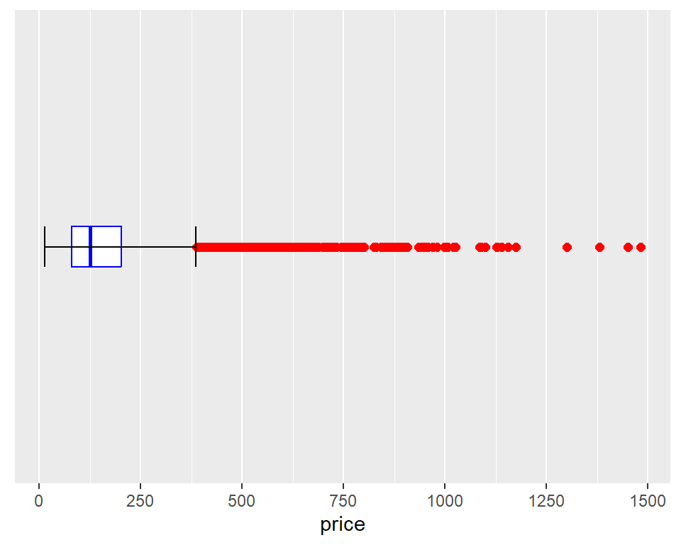

```r
data %>%
  filter(price < 1500) %>%
  ggplot(aes(x = price)) +
  geom_boxplot(color = "blue", outlier.color = "red", outlier.size = 2) +
  scale_x_continuous(breaks = seq(from = 0, to = 1500, by = 250)) +
  ylim(-4,4) +
  stat_boxplot(geom ='errorbar') +
  theme(axis.title.y = element_blank(),
              axis.text.y = element_blank(),
              axis.ticks.y = element_blank(),
        panel.grid.minor.y = element_blank(),
        panel.grid.major.y = element_blank())
```

This seems like a better representation of most of the price data for the listings.

As with any property value we may expect things like the number of bedrooms in the listing to be a predictor of price. Larger properties should have higher bedroom counts and thus be more expensive to rent:

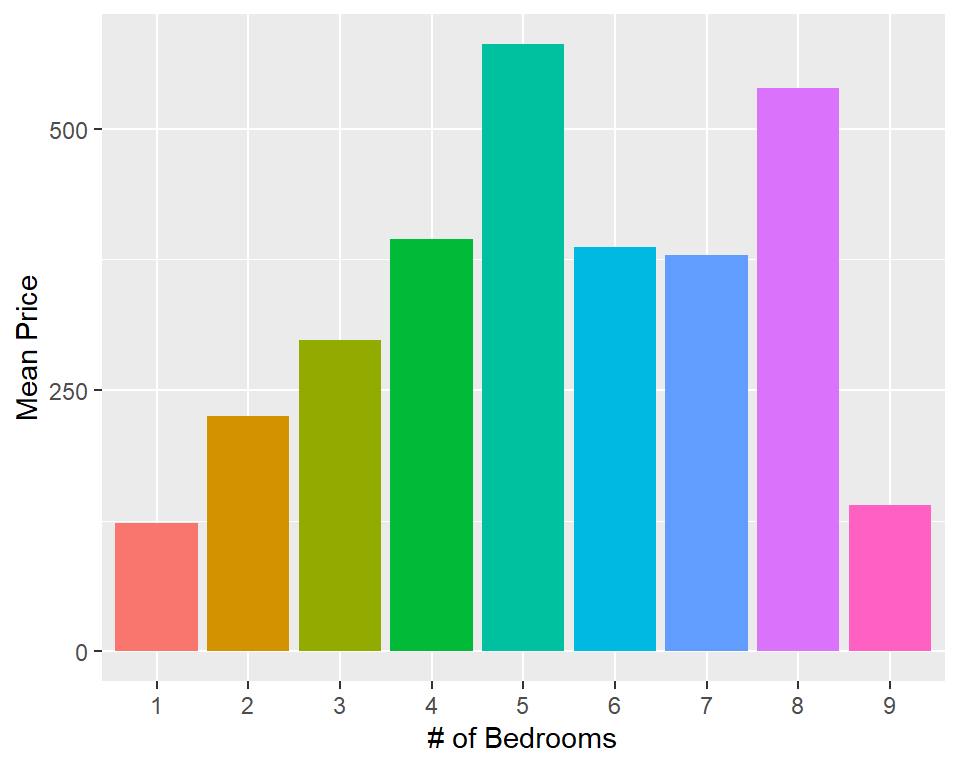

```r
data %>%
  filter(price < 1500) %>%
  mutate(bedrooms = as.factor(bedrooms)) %>%
  select(price, bedrooms) %>%
  group_by(bedrooms) %>%
  summarize(mean_price = mean(price)) %>%
  ungroup() %>%
  ggplot(aes(x = bedrooms, y = mean_price, fill = bedrooms)) +
  geom_bar(stat = "identity") +
  scale_y_continuous(breaks = seq(from = 0, to = 1500, by = 250)) +
  theme(legend.position = "none") +
  xlab("# of Bedrooms") +
  ylab("Mean Price")
```

There appears to be only 1 listing with 9 bedrooms.

```r
data %>%
  filter(price < 1500 & bedrooms == 9)
```

| id | listing_url | scrape_id | last_scraped | source | name | description | neighborhood_overview | picture_url | host_id | host_url | host_name | host_since | host_location | host_about | host_response_time | host_response_rate | host_acceptance_rate | host_is_superhost | host_thumbnail_url | host_picture_url | host_neighbourhood | host_listings_count | host_total_listings_count | host_verifications | host_has_profile_pic | host_identity_verified | neighbourhood | neighbourhood_cleansed | neighbourhood_group_cleansed | … |
| --- | --- | --- | --- | --- | --- | --- | --- | --- | --- | --- | --- | --- | --- | --- | --- | --- | --- | --- | --- | --- | --- | --- | --- | --- | --- | --- | --- | --- | --- | --- |
| 38041763 | https://www.airbnb.com/rooms/38041763 | 2.023031e+13 | 2023-03-10 | city scrape | Luxury condo Downtown Toronto | My place is very clean, fresh and pretty large. I have really nice terrace where you can chill . Big tv 70 inch tv with sound system. This is a smart home that you can control all lights through Alexa… | There is very nice grocery store ( one of my favorite, Tim Hortons , CN tower/ Rogers center 15 minutes walking | https://a0.muscache.com/pictures/b710e682-237a-417e-94fa-2b7c9d179a7f.jpg | 240737008 | https://www.airbnb.com/users/show/240737008 | Maksim | 2019-02-03 | Toronto, Canada | Bodybuilder, fitness model! Love traveling:) | within a day | 71% | 29% | FALSE | https://a0.muscache.com/im/pictures/user/edcf26fc-e6a6-4df5-8cde-20ba0ae9229a.jpg?aki_policy=profile_small | https://a0.muscache.com/im/pictures/user/edcf26fc-e6a6-4df5-8cde-20ba0ae9229a.jpg?aki_policy=profile_x_medium | NA | 1 | 3 | ['email', 'phone'] | TRUE | TRUE | Toronto, Ontario, Canada | Niagara | NA | … |

Because the price is so wildly off from the overall trend I think it’s best to remove this point in the model.

Next it seems likely review scores should be a strong predictor of prices:

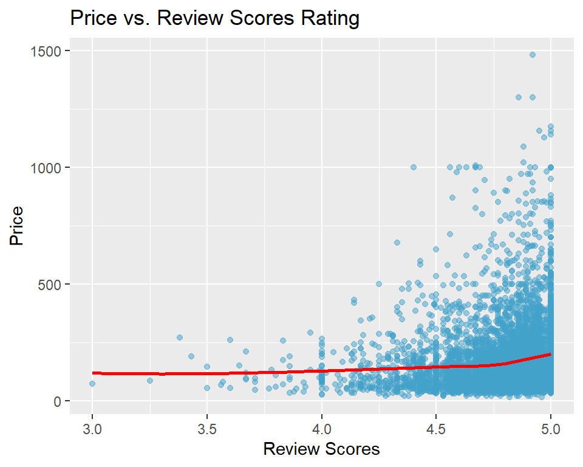

```r
data %>%
  filter(price < 1500 & bedrooms < 9 & number_of_reviews > 5) %>%
  ggplot(aes(x = review_scores_rating, y = price)) +
    geom_point(alpha = 0.5, color = "#43a2ca") +
    geom_smooth(method = "loess", se = FALSE, color = "red") +
  labs(title = "Price vs. Review Scores Rating",
       x = "Review Scores",
       y = "Price")
```

We should also check for linear correlations between predictors, we can visualize this via a correlation matrix

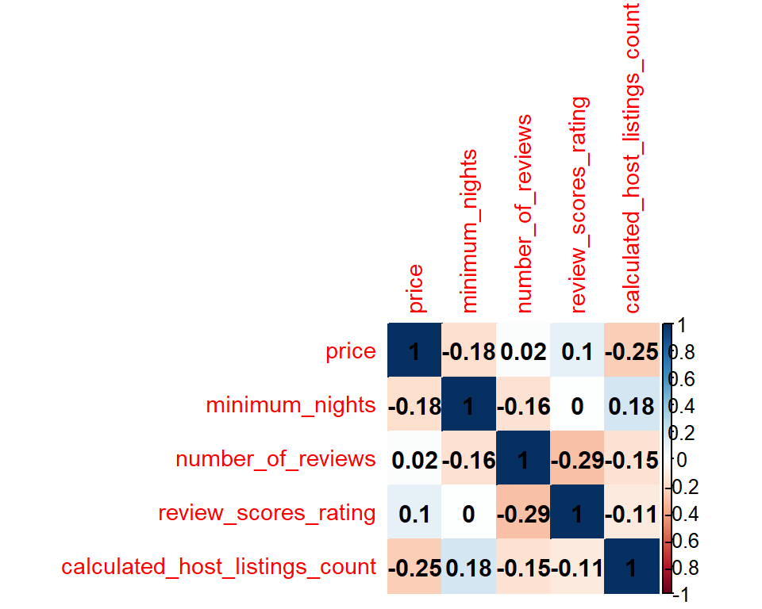

```r
df <- data %>%
  filter(price < 1500 & bedrooms < 9) %>%
  select(price, minimum_nights, number_of_reviews, review_scores_rating, calculated_host_listings_count)

corrplot(cor(as.matrix(df),method = "spearman"),
                 method = "color",
                  tl.cex = 0.9,
                 number.cex = 0.95,
                 addCoef.col = "black")
```

# Model Selection

```r
df <- data %>%
  filter(price < 1500 & bedrooms < 9) %>%
  select(id, longitude, latitude, price, room_type, minimum_nights, number_of_reviews, last_review, reviews_per_month, availability_365, bedrooms, calculated_host_listings_count,
         number_of_reviews_ltm) %>% drop_na()
```

We would like to find a model that outperforms linear regression performed using all predictors. This is the simplest model we could employ, though we found no evidence that the predictors have linear relationships with price it will serve as a good baseline to assess the performance of other models which are more computationally expensive to train.

```r
set.seed(1)

train_data <- df %>%
  sample_frac(0.70)

test_data <- anti_join(df, train_data, by = 'id')

# Train model
mod.lm <- lm(price ~ .-id, data = train_data)

# Test model on test set
predictions <- predict(mod.lm, test_data, type = "response")

# Calculating RMSE and MAE
mae <- mean(abs(test_data$price - predictions))
cat("Mean Absolute Error (MAE):", mae, "\n")
```

```
## Mean Absolute Error (MAE): 70.4116
```

```r
rmse <- sqrt(mean((test_data$price - predictions)^2))
cat("Root Mean Squared Error (RMSE):", rmse, "\n")
```

```
## Root Mean Squared Error (RMSE): 115.2373
```

Now we may want to test some other model techniques namely ones that contain some sort of feature selection. To do that we will use random forest and lasso regression. Ideally these models will produce lower error rates then our standard linear model as they should capture some of the non linear relationships we observed in the data exploration phase.

```r
set.seed(1)

# Split data train/test

train_data <- df %>%
  sample_frac(0.70)

test_data <- anti_join(df, train_data, by = 'id')

# Defining Control Parameters
control_rfe <- rfeControl(functions = rfFuncs,
                          method = "cv",
                          number = 5,
                          verbose = FALSE)

# Defining Predictors
predictors <- names(train_data[, !(names(train_data) %in% c("price"))])

# Run RFE
rfe_result <- rfe(train_data[, predictors],
                  train_data$price,
                  sizes = c(1:10),
                  rfeControl = control_rfe)
print(rfe_result)
```

```
##
## Recursive feature selection
##
## Outer resampling method: Cross-Validated (5 fold)
##
## Resampling performance over subset size:
##
##  Variables  RMSE Rsquared   MAE RMSESD RsquaredSD MAESD Selected
##          1 124.5   0.2622 80.21  4.773    0.05062 1.517
##          2 121.0   0.3085 76.37  4.945    0.03255 1.510
##          3 118.4   0.3466 72.22  5.132    0.02837 1.733
##          4 115.0   0.3899 68.76  5.333    0.02634 1.715
##          5 112.9   0.4161 66.54  5.224    0.01908 1.881
##          6 107.1   0.4540 61.56  4.648    0.03025 1.888
##          7 105.5   0.4724 60.63  5.100    0.02801 2.186
##          8 104.7   0.4826 60.18  5.232    0.03571 1.692
##          9 103.8   0.4885 59.55  5.544    0.03931 2.010
##         10 103.4   0.4947 58.99  6.151    0.03456 1.877
##         12 102.8   0.5008 58.70  5.806    0.02968 1.701        *
##
## The top 5 variables (out of 12):
##    bedrooms, room_type, minimum_nights, latitude, longitude
```

```r
set.seed(1)

best_features <- predictors[rfe_result$optVariables]

# Train the final model with the selected features
final_model <- randomForest(price ~ ., data = train_data[, c("price", rfe_result$optVariables)])

# Evaluate the model performance on the test dataset
predictions <- predict(final_model, newdata = test_data[, rfe_result$optVariables])
performance <- postResample(predictions, test_data$price)
print(performance)
```

```
##        RMSE    Rsquared         MAE
## 102.6226866   0.5156927  57.6238971
```

As expected random forest performs better then the standard linear regression. Now we build a lasso regression model.

```r
set.seed(1)

# Creating model matrix of predictors for Lasso fucntion
X <- model.matrix(price ~ . -1, data = train_data)
X.test <- model.matrix(price ~ . -1, data = test_data)
Y <- train_data$price
Y.test <- test_data$price

# Fit LASSO model
lasso.cv <- cv.glmnet(X, Y, alpha = 1, nfolds = 5)
# Finding optimal lambda
optimal <- lasso.cv$lambda.min
# Fit the optimal lambda model
lasso.mod <- glmnet(X, Y, alpha = 1, lambda = optimal)

# Make predictions on new test data
lasso.pred <- predict(lasso.mod, optimal, newx = X.test)

# Compute error
mae <- mean(abs(lasso.pred-Y.test))
cat("Mean Absolute Error (MAE):", mae, "\n")
```

```
## Mean Absolute Error (MAE): 70.27905
```

```r
rmse <- sqrt(mean((lasso.pred-Y.test)^2))
cat("Root Mean Squared Error (RMSE):", rmse, "\n")
```

```
## Root Mean Squared Error (RMSE): 115.1936
```

In this case we find the lasso not to be a significant improvement over the linear regression model. This is most likely caused by lasso not capturing non linear relationships which are captured in random forest.

The next method we will assess is gradient boosting machines

```r
set.seed(1)

gbm_model <- gbm(price ~ .-last_review,data = train_data,  distribution = "gaussian",
                 n.trees = 1000,
                 interaction.depth = 3,
                 shrinkage = 0.01,
                 n.minobsinnode = 10,
                 cv.folds = 5,
                 verbose = FALSE)

# Determine the optimal tree number
optimal_trees <- gbm.perf(gbm_model, method = "cv")
```

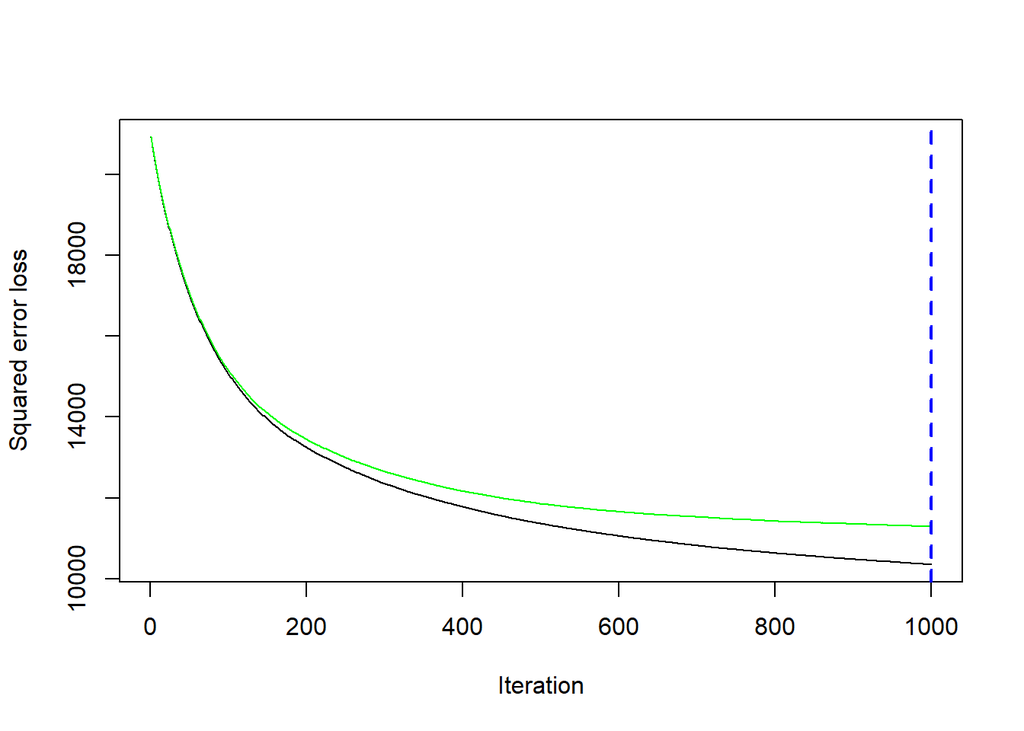

```r
# Compute error rates
predictions <- predict(gbm_model, newdata = test_data, n.trees = optimal_trees)
performance <- postResample(predictions, test_data$price)
print(performance)
```

```
##        RMSE    Rsquared         MAE
## 105.0198847   0.4929508  59.5950594
```

```r
set.seed(1)

# Normalizing train and test split
preprocess_params <- preProcess(train_data[, -which(names(train_data) == "price")], method = c("center", "scale"))

train_data_scaled <- predict(preprocess_params, train_data)
test_data_scaled <- predict(preprocess_params, test_data)
test_data_scaled$price <- test_data$price

# Training model with svm()
svm_model <- svm(price ~ .,
                 data = train_data_scaled,
                 kernel = "radial",
                 cost = 1,
                 gamma = 0.1,
                 epsilon = 0.1)

# Computing error rates
predictions <- predict(svm_model, newdata = test_data_scaled)
performance <- postResample(predictions, test_data_scaled$price)
print(performance)
```

```
##        RMSE    Rsquared         MAE
## 108.9972980   0.4745813  56.9053357
```

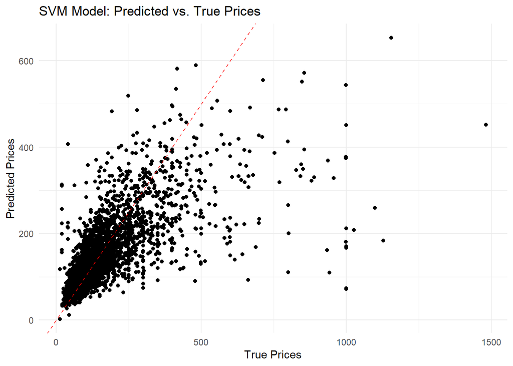

```r
library(ggplot2)

pred_vs_true <- data.frame(Predicted = predictions, True = test_data_scaled$price)
ggplot(pred_vs_true, aes(x = True, y = Predicted)) +
  geom_point() +
  geom_abline(intercept = 0, slope = 1, color = "red", linetype = "dashed") +
  labs(title = "SVM Model: Predicted vs. True Prices",
       x = "True Prices",
       y = "Predicted Prices") +
  theme_minimal()
```